# Project 1: Wrangling, Exploration, Visualization

```r
# Let's you see the change in GDP Growth over the years, the
# USA hit its peak cumulative GDP growth in 1950 after
# recovering from the Great Depression, and has been
# fluctuating with an overall decline ever since


# Tables of counts of categorical variables
library(knitr)
table1 <- proj_join %>% group_by(Country) %>% summarize_if(is.numeric,
    list(mean = mean, max = max, min = min)) %>% pivot_longer(-1) %>%
    pivot_wider(names_from = "name", values_from = "value")
table1 <- table1 %>% kable(digits = 2, align = "c", col.names = str_to_title(names(.)),
    caption = "Summary Statistics")
table1
```

Summary Statistics

| Country | Year_mean | Gdp Yearly Growth_mean | Half-Time Away Goals_mean | Home Team Goals_mean | Roundid_mean | Matchid_mean | Home_team_goals_mean | Away_team_goals_mean | Year_max | Gdp Yearly Growth_max | Half-Time Away Goals_max | Home Team Goals_max | Roundid_max | Matchid_max | Home_team_goals_max | Away_team_goals_max | Year_min | Gdp Yearly Growth_min | Half-Time Away Goals_min | Home Team Goals_min | Roundid_min | Matchid_min | Home_team_goals_min | Away_team_goals_min |
| --- | --- | --- | --- | --- | --- | --- | --- | --- | --- | --- | --- | --- | --- | --- | --- | --- | --- | --- | --- | --- | --- | --- | --- | --- |
| arg | 1982.17 | 2.00 | 0.29 | 2.17 | 7940631.33 | 32926214.60 | 3.10 | 1.19 | 2010 | 8.88 | 2 | 6 | 97410200 | 300061505 | 9 | 5 | 1930 | -11.12 | 0 | 0 | 201 | 26 | 0 | 0 |
| aus | 1991.00 | 2.75 | 0.75 | 1.25 | 24415086.50 | 99368846.50 | 1.25 | 2.00 | 2010 | 3.14 | 2 | 3 | 97410100 | 300061467 | 3 | 5 | 1974 | 2.46 | 0 | 0 | 262 | 1953 | 0 | 0 |
| aut | 1966.31 | 4.02 | 0.77 | 2.38 | 523.69 | 1188.15 | 3.46 | 2.08 | 1990 | 10.18 | 4 | 7 | 3485 | 2224 | 12 | 9 | 1934 | -0.40 | 0 | 0 | 204 | 43 | 0 | 0 |
| bel | 1989.43 | 2.54 | 0.43 | 1.43 | 3139681.64 | 3141532.57 | 2.14 | 1.36 | 2002 | 6.30 | 2 | 3 | 43950100 | 43950046 | 5 | 4 | 1970 | 1.32 | 0 | 0 | 250 | 56 | 0 | 0 |
| bol | 1994.00 | 4.85 | 1.00 | 1.00 | 337.00 | 3075.00 | 1.00 | 4.00 | 1994 | 4.85 | 1 | 1 | 337 | 3075 | 1 | 4 | 1994 | 4.85 | 1 | 1 | 337 | 3075 | 1 | 4 |
| bra | 1976.94 | 5.39 | 0.35 | 2.35 | 7864299.53 | 20357791.57 | 3.22 | 1.08 | 2010 | 10.93 | 2 | 7 | 97410300 | 300061500 | 10 | 5 | 1930 | -6.46 | 0 | 0 | 201 | 25 | 0 | 0 |
| can | 1986.00 | 2.93 | 0.00 | 0.00 | 308.00 | 468.00 | 0.00 | 1.00 | 1986 | 2.93 | 0 | 0 | 308 | 468 | 0 | 1 | 1986 | 2.93 | 0 | 0 | 308 | 468 | 0 | 1 |
| chn | 2002.00 | 10.92 | 0.00 | 0.00 | 43950100.00 | 43950012.00 | 0.00 | 2.00 | 2002 | 10.92 | 0 | 0 | 43950100 | 43950012 | 0 | 2 | 2002 | 10.92 | 0 | 0 | 43950100 | 43950012 | 0 | 2 |
| civ | 2008.00 | 1.85 | 1.00 | 1.50 | 48829911.00 | 198735763.50 | 2.00 | 2.00 | 2010 | 3.00 | 2 | 3 | 97410100 | 300061489 | 4 | 4 | 2006 | 0.70 | 0 | 0 | 249722 | 97410038 | 0 | 0 |
| cmr | 1998.44 | 1.82 | 0.56 | 1.11 | 9822440.22 | 76448345.11 | 1.33 | 2.22 | 2010 | 6.53 | 2 | 2 | 43950100 | 300061475 | 3 | 6 | 1990 | -2.54 | 0 | 0 | 322 | 102 | 0 | 0 |
| col | 1996.67 | 2.02 | 1.33 | 0.67 | 788.33 | 6859.33 | 1.00 | 3.00 | 1998 | 5.08 | 2 | 1 | 1014 | 8770 | 2 | 5 | 1994 | 0.49 | 0 | 0 | 337 | 3053 | 0 | 0 |
| cub | 1938.00 | -22.46 | 0.50 | 2.50 | 206.00 | 1156.50 | 2.50 | 2.50 | 1938 | -22.46 | 1 | 3 | 206 | 1157 | 3 | 3 | 1938 | -22.46 | 0 | 2 | 206 | 1156 | 2 | 2 |
| cze | 2006.00 | 7.10 | 1.00 | 0.00 | 97410100.00 | 97410033.50 | 0.00 | 3.00 | 2006 | 7.10 | 1 | 0 | 97410100 | 97410041 | 0 | 3 | 2006 | 7.10 | 1 | 0 | 97410100 | 97410026 | 0 | 3 |
| ecu | 2004.67 | 3.35 | 0.67 | 1.33 | 79590100.00 | 79590031.67 | 1.67 | 1.67 | 2006 | 4.51 | 2 | 3 | 97410100 | 97410033 | 4 | 5 | 2002 | 1.03 | 0 | 0 | 43950100 | 43950044 | 0 | 0 |
| esp | 1987.00 | 3.55 | 0.29 | 1.75 | 16742420.64 | 48868236.82 | 2.29 | 1.11 | 2010 | 11.79 | 1 | 6 | 97410200 | 300111112 | 8 | 4 | 1934 | 0.32 | 0 | 0 | 204 | 181 | 0 | 0 |
| fra | 1981.85 | 2.42 | 0.38 | 2.35 | 10893782.27 | 33957851.12 | 3.27 | 1.50 | 2010 | 5.28 | 2 | 7 | 97410100 | 300061451 | 9 | 5 | 1930 | -2.77 | 0 | 0 | 201 | 422 | 0 | 0 |
| gha | 2008.67 | 5.93 | 0.67 | 1.00 | 32636514.67 | 232510993.00 | 2.00 | 1.67 | 2010 | 6.62 | 1 | 2 | 97410100 | 300061469 | 4 | 2 | 2006 | 4.55 | 0 | 0 | 249722 | 97410042 | 0 | 1 |
| hun | 1958.44 | 4.02 | 0.50 | 4.06 | 441.22 | 1228.44 | 5.89 | 1.56 | 1986 | 6.54 | 2 | 10 | 3489 | 1599 | 13 | 4 | 1934 | 0.63 | 0 | 0 | 204 | 475 | 0 | 0 |
| irl | 1993.20 | 7.82 | 0.40 | 0.40 | 8790280.80 | 8790741.40 | 0.40 | 0.80 | 2002 | 8.65 | 1 | 1 | 43950100 | 43950002 | 1 | 2 | 1990 | 5.86 | 0 | 0 | 322 | 152 | 0 | 0 |
| irn | 2006.00 | 5.82 | 0.00 | 1.00 | 97410100.00 | 97410040.00 | 1.00 | 1.00 | 2006 | 5.82 | 0 | 1 | 97410100 | 97410040 | 1 | 1 | 2006 | 5.82 | 0 | 1 | 97410100 | 97410040 | 1 | 1 |
| irq | 1986.00 | 5.61 | 1.00 | 0.50 | 308.00 | 527.00 | 0.50 | 2.50 | 1986 | 5.61 | 2 | 1 | 308 | 627 | 1 | 4 | 1986 | 5.61 | 0 | 0 | 308 | 427 | 0 | 1 |
| ita | 1978.80 | 2.68 | 0.22 | 1.80 | 10463483.35 | 21366752.89 | 2.45 | 0.93 | 2010 | 6.25 | 1 | 7 | 97410600 | 300061484 | 10 | 3 | 1934 | 1.01 | 0 | 0 | 204 | 28 | 0 | 0 |
| jam | 1998.00 | -0.57 | 1.00 | 1.00 | 1014.00 | 8736.00 | 2.00 | 4.00 | 1998 | -0.57 | 1 | 1 | 1014 | 8736 | 2 | 4 | 1998 | -0.57 | 1 | 1 | 1014 | 8736 | 2 | 4 |
| jpn | 2003.00 | 0.35 | 0.38 | 0.75 | 40865293.75 | 78343645.88 | 1.00 | 1.62 | 2010 | 4.64 | 1 | 2 | 97410100 | 300061477 | 2 | 5 | 1998 | -2.98 | 0 | 0 | 1014 | 8751 | 0 | 0 |
| kor | 1997.33 | 8.70 | 0.67 | 1.33 | 22788611.08 | 47773750.08 | 1.75 | 2.08 | 2010 | 16.27 | 3 | 2 | 97410100 | 300061459 | 3 | 6 | 1986 | -3.86 | 0 | 0 | 308 | 175 | 0 | 0 |
| mar | 1991.00 | 8.09 | 0.50 | 0.75 | 492.00 | 3263.50 | 1.00 | 1.75 | 1998 | 9.87 | 1 | 2 | 1014 | 8725 | 3 | 3 | 1986 | 7.29 | 0 | 0 | 308 | 574 | 0 | 0 |
| mex | 1987.87 | 3.45 | 0.40 | 1.40 | 21794854.33 | 41783156.00 | 2.07 | 1.13 | 2010 | 6.75 | 1 | 4 | 97410100 | 300061450 | 5 | 3 | 1958 | -3.19 | 0 | 0 | 220 | 463 | 0 | 0 |
| nga | 1999.14 | 5.59 | 0.57 | 1.29 | 6314792.71 | 49156227.14 | 2.00 | 2.14 | 2010 | 21.35 | 2 | 3 | 43950100 | 300111115 | 5 | 6 | 1994 | 0.91 | 0 | 0 | 337 | 3061 | 0 | 0 |
| nor | 1994.00 | 5.46 | 0.00 | 1.00 | 337.00 | 3055.00 | 1.00 | 0.00 | 1994 | 5.46 | 0 | 1 | 337 | 3055 | 1 | 0 | 1994 | 5.46 | 0 | 1 | 337 | 3055 | 1 | 0 |
| nzl | 2010.00 | 1.63 | 0.00 | 1.00 | 249722.00 | 300061483.00 | 1.00 | 1.00 | 2010 | 1.63 | 0 | 1 | 249722 | 300061483 | 1 | 1 | 2010 | 1.63 | 0 | 1 | 249722 | 300061483 | 1 | 1 |
| per | 1975.60 | 3.22 | 0.60 | 2.60 | 269.80 | 1872.40 | 3.40 | 1.40 | 1982 | 7.79 | 1 | 4 | 293 | 2451 | 7 | 3 | 1970 | 0.03 | 0 | 0 | 250 | 833 | 0 | 0 |
| pol | 1982.25 | 2.49 | 0.25 | 1.69 | 8835283.62 | 8836377.94 | 2.50 | 1.12 | 2006 | 6.29 | 1 | 5 | 97410100 | 97410002 | 5 | 3 | 1974 | -0.85 | 0 | 0 | 262 | 701 | 0 | 0 |
| prk | 1980.67 | 0.92 | 1.00 | 0.67 | 83399.33 | 100021591.33 | 1.00 | 2.33 | 2010 | 1.65 | 2 | 1 | 249722 | 300061486 | 2 | 5 | 1966 | -0.55 | 0 | 0 | 238 | 1609 | 0 | 0 |
| rou | 1986.00 | -0.03 | 0.56 | 1.67 | 665.33 | 5256.22 | 2.22 | 2.00 | 1998 | 7.19 | 1 | 3 | 1024 | 8780 | 5 | 5 | 1930 | -5.00 | 0 | 0 | 201 | 1098 | 0 | 0 |
| rus | 1998.00 | -3.97 | 0.00 | 4.00 | 21975218.50 | 21976547.00 | 5.50 | 0.50 | 2002 | 4.83 | 0 | 6 | 43950100 | 43950015 | 9 | 1 | 1994 | -12.78 | 0 | 2 | 337 | 3079 | 2 | 0 |
| sen | 2002.00 | 1.22 | 0.00 | 1.50 | 43950200.00 | 43950047.00 | 3.00 | 2.00 | 2002 | 1.22 | 0 | 3 | 43950300 | 43950060 | 6 | 3 | 2002 | 1.22 | 0 | 0 | 43950100 | 43950034 | 0 | 1 |
| srb | 2010.00 | -1.34 | 0.00 | 0.00 | 249722.00 | 300061471.00 | 0.00 | 1.00 | 2010 | -1.34 | 0 | 0 | 249722 | 300061471 | 0 | 1 | 2010 | -1.34 | 0 | 0 | 249722 | 300061471 | 0 | 1 |
| svk | 2010.00 | 4.34 | 0.50 | 1.50 | 249722.00 | 300061480.50 | 2.00 | 2.50 | 2010 | 4.34 | 1 | 3 | 249722 | 300061481 | 4 | 3 | 2010 | 4.34 | 0 | 0 | 249722 | 300061480 | 0 | 2 |
| svn | 2007.33 | 1.74 | 0.33 | 1.00 | 14816514.67 | 214690988.33 | 2.00 | 2.33 | 2010 | 3.62 | 1 | 2 | 43950100 | 300061463 | 4 | 3 | 2002 | 0.80 | 0 | 0 | 249722 | 43950040 | 0 | 2 |
| swe | 1974.30 | 4.04 | 0.41 | 1.96 | 12099368.78 | 12100277.37 | 2.81 | 1.33 | 2006 | 8.10 | 1 | 8 | 97410100 | 97410035 | 12 | 3 | 1934 | -0.24 | 0 | 0 | 204 | 128 | 0 | 0 |
| tun | 1997.00 | 3.96 | 0.50 | 1.50 | 46327644.50 | 46328131.25 | 2.00 | 2.00 | 2006 | 7.00 | 1 | 3 | 97410100 | 97410016 | 3 | 2 | 1978 | 1.55 | 0 | 0 | 278 | 2433 | 0 | 2 |
| tur | 1978.00 | 2.35 | 0.00 | 5.00 | 21975155.50 | 21975673.00 | 8.00 | 0.00 | 2002 | 7.70 | 0 | 7 | 43950100 | 43950042 | 11 | 0 | 1954 | -3.00 | 0 | 3 | 211 | 1304 | 5 | 0 |
| ukr | 2006.00 | 7.44 | 0.00 | 1.00 | 97410100.00 | 97410048.00 | 1.00 | 0.00 | 2006 | 7.44 | 0 | 1 | 97410100 | 97410048 | 1 | 0 | 2006 | 7.44 | 0 | 1 | 97410100 | 97410048 | 1 | 0 |
| usa | 1985.08 | 2.09 | 0.69 | 1.31 | 10912585.38 | 57039495.62 | 2.08 | 2.08 | 2010 | 12.64 | 2 | 3 | 97410100 | 300061503 | 6 | 7 | 1930 | -8.89 | 0 | 0 | 201 | 355 | 0 | 0 |

```r
table2 <- proj_join %>% group_by(Country, who_wins) %>% summarize(count = n())
table2 <- table2 %>% kable(digits = 2, align = "c", col.names = str_to_title(names(.)),
    caption = "Frequency of Countries in the WorldCup")
table2
```

Frequency of Countries in the WorldCup

| Country | Who_wins | Count |
| --- | --- | --- |
| arg | Away | 13 |
| arg | Home | 35 |
| aus | Away | 2 |
| aus | Home | 2 |
| aut | Away | 4 |
| aut | Home | 9 |
| bel | Away | 5 |
| bel | Home | 9 |
| bol | Away | 1 |
| bra | Away | 20 |
| bra | Home | 52 |
| can | Away | 1 |
| chn | Away | 1 |
| civ | Away | 2 |
| cmr | Away | 6 |
| cmr | Home | 3 |
| col | Away | 2 |
| col | Home | 1 |
| cub | Away | 2 |
| cze | Away | 2 |
| ecu | Away | 1 |
| ecu | Home | 2 |
| esp | Away | 13 |
| esp | Home | 15 |
| fra | Away | 9 |
| fra | Home | 17 |
| gha | Away | 2 |
| gha | Home | 1 |
| hun | Away | 3 |
| hun | Home | 15 |
| irl | Away | 5 |
| irn | Away | 1 |
| irq | Away | 2 |
| ita | Away | 16 |
| ita | Home | 39 |
| jam | Away | 1 |
| jpn | Away | 6 |
| jpn | Home | 2 |
| kor | Away | 9 |
| kor | Home | 3 |
| mar | Away | 4 |
| mex | Away | 6 |
| mex | Home | 9 |
| nga | Away | 5 |
| nga | Home | 2 |
| nor | Home | 1 |
| nzl | Away | 1 |
| per | Away | 2 |
| per | Home | 3 |
| pol | Away | 5 |
| pol | Home | 11 |
| prk | Away | 2 |
| prk | Home | 1 |
| rou | Away | 5 |
| rou | Home | 4 |
| rus | Home | 2 |
| sen | Away | 1 |
| sen | Home | 1 |
| srb | Away | 1 |
| svk | Away | 1 |
| svk | Home | 1 |
| svn | Away | 2 |
| svn | Home | 1 |
| swe | Away | 11 |
| swe | Home | 16 |
| tun | Away | 2 |
| tun | Home | 2 |
| tur | Home | 2 |
| ukr | Home | 1 |
| usa | Away | 7 |
| usa | Home | 6 |

The data set “proj_join” now contains data about the World Cup matches, total goals for each time, the year it occurred and more; organized by country and their change in annual GDP for that year. As seen when tidying, the total amount of goals for both the home and away team had been calculated from the “World Cup Matches” data set and a new variable entitled “who_wins” noted which team scored the most goals per match. Proj_join was then subjected to a series of wrangling functions in order to gain a better understanding of which countries are most active in the tournament, with Brazil taking the lead. An interesting finding is that countries who were most active in the World Cup overall (most of Latin America and Europe) tended to have a higher correlation to an increase in GDP over the years they played. Whereas Turkey, for example, actually held the record for the highest average number of goals scored as a home team (8) and even made 11 in 1954 but simultaneously experienced a drop in GDP that year by three points. This could be connected to the fact that Turkey as a team had a standard deviation of 4.24 goals in their years playing in the tournament as a home team, indicating that their performance varied in addition to their GDP. More wrangling was applied including a table of counts of summary statistics for each numeric variable in proj_join and another showing the frequency of the countries involved in the World Cup. The summary statistics outlined in the first table showed that China experienced the highest average GDP yearly growth of about 10 points. Although this could be due to multiple other economic factors, China has been under watch as it aims to become one of the world’s superpowers in soccer and has been implicated in sponsoring FIFA during the organization’s biggest scandal(s). The close relationship that FIFA holds with some of China’s wealthiest businessman is considered even more suspicious, when noting that China has only ever played one match in the World Cup.

#### Visualizing

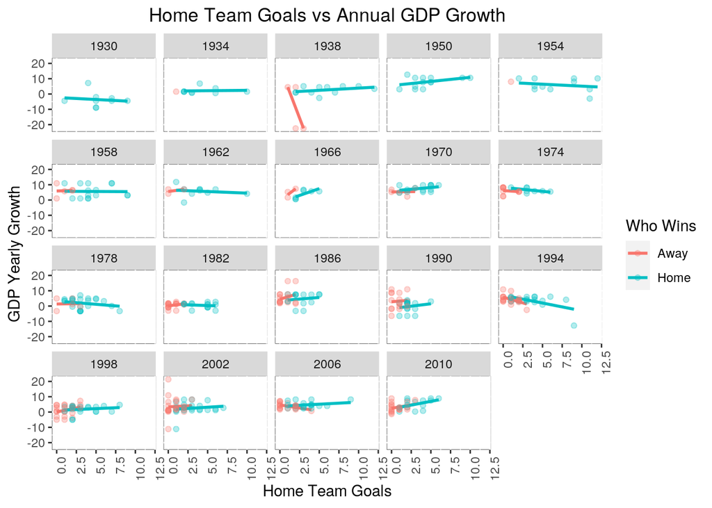

```r
proj_join %>% ggplot(aes(x = Home_Team_Goals, y = `GDP Yearly Growth`,
    color = who_wins)) + geom_smooth(method = "lm", se = F) +
    geom_point(alpha = 0.3) + ggtitle("Home Team Goals vs Annual GDP Growth") +
    ylab("GDP Yearly Growth") + xlab("Home Team Goals") + facet_wrap(~Year) +
    scale_x_continuous(limits = c(0, 12)) + scale_y_continuous(breaks = seq(-20,
    20, 10)) + theme(plot.title = element_text(hjust = 0.5),
    axis.text.x = element_text(angle = 90, hjust = 1), panel.background = element_rect(fill = "white",
        color = "black", size = 0.2, linetype = "solid")) + guides(color = guide_legend("Who Wins"))
```

The plot above shows the relationship between the number of goals scored by the home team and the yearly growth of GDP, faceted by year. The legend indicates whether the away or home team won, and as expected as the number of home team goals increases the is a decline in the amount of wins amassed by the away teams. One common factor that can be observed from the plot above is that there is little to no correlation between the number of goals scored by the home team and the GDP growth they experienced. This trend remains fairly constant for all years reported in the data set, indicating that the assignment of “home team” does not have any correlation to overall success in the match nor the country’s economy.

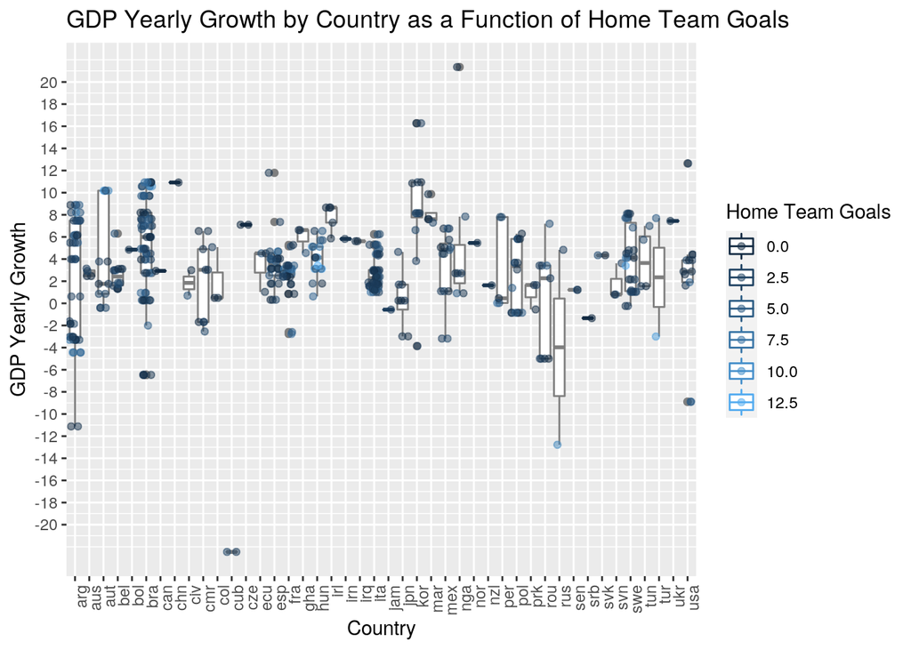

```r
proj_join %>% ggplot(aes(x = Country, y = `GDP Yearly Growth`,
    color = Home_Team_Goals)) + geom_boxplot() + geom_jitter(alpha = 0.5,
    aes(color = Home_Team_Goals)) + ggtitle("GDP Yearly Growth by Country as a Function of Home Team Goals") +
    theme(axis.text.x = element_text(angle = 90, hjust = 1, vjust = 1)) +
    scale_y_continuous(name = "GDP Yearly Growth", seq(-20, 20,
        2)) + guides(color = guide_legend("Home Team Goals"))
```

This grouped box plot is organized by every country found in the data set mapping each value for their GDP Yearly growth from 1930-2010, and has the number of their goals scored as a home team as a function of this growth. The plot shows on average the number of home team goals is not related to whether the country’s GDP would increase or decrease. There are a few countries that showed a wider range of GDP values over the years; namely Argentina, Austria, Cameroon, Romania, and Russia. While a select few of these countries’ changes over the years can be related to other factors such as their independence and role as a world power, the one that is the most worthy of noting is Russia. Russia was heavily implicated as one of the countries that had bribed FIFA officials to award them the World Cup in 2018. On the plot, when Russia performed better in the World Cup it actually coincided with their highest decline in GDP that year. However, the year of their highest GDP growth overlaps with their lowest average score as a home team. This trend may seem backwards, as one would expect better performance in a better economic year, however Russia would not have to bribe FIFA officials if they were certain they could win on their own.

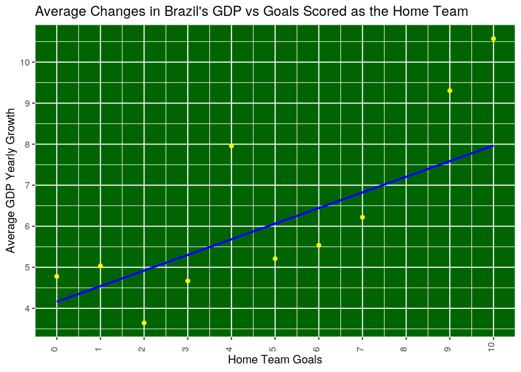

```r
proj_join %>% filter(Country == "bra") %>% ggplot(aes(x = Home_Team_Goals,
    y = `GDP Yearly Growth`)) + geom_point(stat = "summary",
    fun = mean, color = "yellow") + geom_smooth(method = "lm",
    se = F, color = "blue") + theme(axis.text.x = element_text(angle = 90,
    vjust = 0.1, hjust = 0.1), panel.background = element_rect(fill = "darkgreen",
    color = "white", linetype = "solid")) + ggtitle("Average Changes in Brazil's GDP vs Goals Scored as the Home Team") +
    scale_y_continuous(name = "Average GDP Yearly Growth", breaks = seq(0,
        15, 1)) + scale_x_continuous(name = "Home Team Goals",
    breaks = (seq(0, 10, 1)))
```

This final plot focuses solely on Brazil’s (note the colors!) performance record with the World Cup by mapping their goals scored each year playing as a home team with their average yearly GDP growth. Surprisingly, while the first plot indicated no correlation between home team goals and GDP growth over each of the years, when narrowing our focus to Brazil there is an apparent positive linear correlation between the two variables. At first glance, this may seem like common sense, as noted previously it is expected that the years in which Brazil is flourishing financially would result in better funding and performance for their team. However, Brazil’s high profile involvement with the World Cup has led many to question whether it is solely their athletic performance that has led them to the country that holds the record for most World Cups won. The controversy is most prominent in Brazil’s own people, who have adopted a hatred for the use of their tax dollars to fund and host World Cups while their country faces some of the most prominent income inequality internationally.

#### Concluding Remarks

Overall, while there is no definitive evidence to suggest a link to a country’s economic success and their World Cup status, the data presented here could possibly suggest a slight degree of corruption within the organization that makes the World Cup happen. Further analyses are recommended to establish a direct conclusion that FIFA could be involved in the corruptive act of accepting bribes.